# Introduction

## ProsperRatingAlpha VS InquiriensLast6Months Destribution:

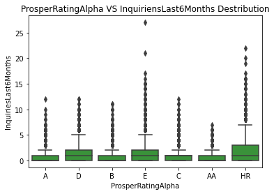

```python
base_color = sns.color_palette()[2]
sns.boxplot(data = df, x = 'ProsperRatingAlpha', y = 'InquiriesLast6Months', color = base_color)
plt.title('ProsperRatingAlpha VS InquiriensLast6Months Destribution')
plt.xlabel('ProsperRatingAlpha')
plt.ylabel('InquiriesLast6Months');
```

Above plot demonstrate that risky borrower make more inquiries while better rating make lesser inquiries than borrowers with prosper rating A, AA ,E .

# LoanStatus

## LoanStatus VS InquiriesLast6Months Destribution

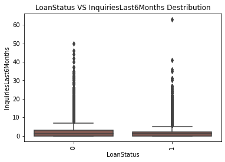

```python
base_color = sns.color_palette()[5]
sns.boxplot(data = df_ls, x = 'LoanStatus', y = 'InquiriesLast6Months', color = base_color)
plt.xticks(rotation = 90)
plt.title('LoanStatus VS InquiriesLast6Months Destribution')
plt.xlabel('LoanStatus')
plt.ylabel('InquiriesLast6Months');
```

from the above plot we can say that Borrowers who have inquired more are prone to be defaulters,while borrowers who completed their loans successfully made less enquries.

## LoanStatus VS DebtToIncomeRatios Destribution

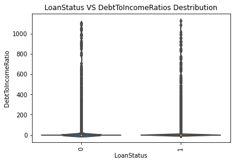

```python
base_color = sns.color_palette()[3]
sns.boxplot(data = df_ls, x = 'LoanStatus', y = 'DebtToIncomeRatio', color = base_color)
plt.xticks(rotation = 90)
sns.violinplot(data = df_ls, x = 'LoanStatus', y = 'DebtToIncomeRatio')
plt.title('LoanStatus VS DebtToIncomeRatios Destribution')
plt.xlabel('LoanStatus')
plt.ylabel('DebtToIncomeRatio');
```

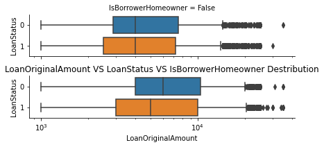

```python
g = sns.catplot(x="LoanOriginalAmount", y="LoanStatus", row="IsBorrowerHomeowner",
                kind="box", orient="h", height=1.5, aspect=4,
                data=df_ls)
g.set(xscale="log")
plt.title('LoanOriginalAmount VS LoanStatus VS IsBorrowerHomeowner Destribution')
```

## LoanOriginalAmount VS EmploymentStatus VS IsBorrowerHomeowner Destribution

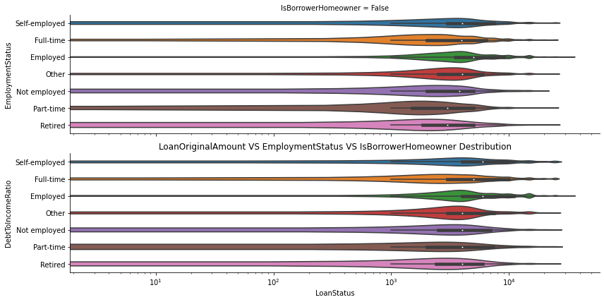

```python
g = sns.catplot(x="LoanOriginalAmount", y="EmploymentStatus", row="IsBorrowerHomeowner",
                kind="violin", orient="h", height=3, aspect=4,
                data=df_ls)
g.set(xscale="log")
plt.title('LoanOriginalAmount VS EmploymentStatus VS IsBorrowerHomeowner Destribution')
plt.xlabel('LoanStatus')
plt.ylabel('DebtToIncomeRatio');
```

From above plot it is clear that borrowers who are SelfEmployed and Employed and who are homeowners borrow higher amount of loan as compared to non-homeowners.

# Reflection:

I successfully analyzed This Prosper Dataset. My analysis was primarily focused at identifying variables affecting Borrower APR, and Prosper Rating and Loan Status. Before starting my analysis I have performed cleaning of the data set as there were lot of missing values in the data, I fixed those value either by replacing them with their median values or by simply deleting them .I have also renamed some of the columns like prosper Rating alpha , also dropped some of the column which are of no use for our further analysis. I also created new column out of existing ones like Listing creation date, Loan origination date.

After cleaning data, I performed univariate exploratory data analysis to observe how data is distributed. Since the dataset has 81 variables, I decided to choose some important ones for detail analysis. I narrowed down the predictive variables by excluding, all-unique, all-same, and more than 50% missing value, these three kinds.

For univariate analysis my variable of interest were Loan original Amount, Borrower Rate, Borrower APR, Occupation, Income Range, Employment status, Monthly Loan payment, Prosper score ,Borrower state ,Loan Original amount ,Lander Yield.

Loan Original amount: The distribution is expected to be right skewed, which is obvious from the histogram, other than couple of peaks. Moreover, we notice that it is quite rare for borrowers to ask for huge amount of loans through prosper.

Borrower APR: As expected the distribution is roughly normal, except couple of peaks on right side of mean. Occupation: Apart from others and professional, Computer programmers and Administrative assistant were the occupation who have payoff their loan.

Income Range : Income range from 25,000−50,000 was the Highest income range for largest number of borrowers. Employment Status: Full time employed and Employed were the highest in frequency.

Borrower State: California, Florida, Illinois are the top three states with highest number of borrower while South Dakota, Wisconsin, North Dakota are state with least number of borrowers. Loan Original amount: Most of the people borrowed loan amount under $10,000. Lander Yield: Lender yield distribution is skewed towards the right direction with highest peak between 0.1 and 0.2.

### Some Important variables that I explored in Bivariate Data Exploration:

Bivariate Data Exploration:

Borrower APR:

Credit Grade VS Borrower APR : For a given Credit Grade, there is significant variation in Borrower APR, hence boxplot is a suitable choice. The boxplot also helped me to observe the skewness in distribution of Borrower APR across different Credit Grade. As expected, the average APR charged to borrowers with poor credit grades is significantly higher than safe borrowers. It is worth adding that the distribution for Credit Grade =HR, distribution is left skewed, which might hint towards higher APR being charged for risky borrowers.

Borrower APR VS Lender Yield: Plots says that Borrower and lender yield are highly correlated. Higher the Borrower APR higher the Lender yield.

Prosper Rating Alpha:

ProsperRatingAlpha VS Inquries last 6 Months: We observe following trends from the boxplot. First, on an average the borrowers who have made frequent inquiries to the bureau have lower prosper rating, hence are more risky. Second, we see significant outliers for every value of ProsperRating. But the variation for safe borrowers, i.e. ProsperRating=AA is lower than other grades. It is expected, since borrowers in excellent credit rating tend not to make several inquiries to the bureau. Next, we also observe skewness in the distribution for InquiriesLast6Months. The mean is significantly higher than median in most of the cases. This can be attributed to the presence of significant number of outliers corresponding to each ProsperRating.

Prosper Rating and Estimated Loss: From the plot we can say that high estimated loss is expected from risky borrowers while less estimated loss is expected from A and AA prosper rating holding.

Loan Status:

1 LoanOriginalAmount : We can see from the above plot that borrowers who borrow small amount of LoanOriginalAmount are more likely to complete their loan on time as compare to the borrowers who borrow large amount .If we see the box plot median value of the Loan original Amount under the borrowers who have successfully completed their loan is 5000 which give us a idea that lesser the loan amount there is high probability to complete the loan on time.

2.ProsperRatingAlpha: Borrowers having prosper Rating A and AA are most likely to pay off their loans, and E and D prosper rating rating are most likely to be the defaulters.

3.Employment status: On observing the Employment status plot we can say that more than half of borrowers who are employed and full time employee pay off their loans but for other categories we don’t have sufficient data to come to any conclusion.

Adding more, I also investigated loan performance at state level. The goal is to identify the state with highest percentage of defaulters in the given dataset. To this end, I identified top five rich and poor states. Since distribution for monthly income is right skewed, we used median as a perfomance measure. I found that North Dakota(ND) has highest percentage of defaulters. One possible reason for large number of default cases in ND can be attributed to the fact that average loan amount for ND exceeds the average income of residents. Identification of additional reasons may require thorough invesigation of this dataset as well as obtaining more data.